# Bayesian modeling and prediction for movies

## Setup

### Load packages

```r
library(ggplot2)
library(dplyr)
library(statsr)
library(BAS)
library(grid)
library(gridExtra)

set.seed(3514)
```

### Load data

Make sure your data and R Markdown files are in the same directory. When loaded your data file will be called `movies`. Delete this note when before you submit your work.

```r
load("movies.Rdata")
```

## Part 1: Data

The dataset “movies” contains 651 randomly sampled movies produced and released before 2016. The movies are from US-based Studios, because MPAA Ratings in the data applies only to American films. This dataset includes information from both Rotten Tomatoes and IMDb.

In this report, we are going to try to generalize the factors that affect the popularity of movies using this data. Such generalization might only be applicable to US-based movies. Since the data is collected randomly from a sample population of all the people who have seen the movie we might be able to use this data to see what affects a movie’s popularity.

This information suggests the dataset should be considered the result of an observational retrospective study that uses a random sampling design to select a representative sample from U.S. movies. When random sampling has been employed in data collection, the results should be generalizable to the target population. Therefore, the results of the analysis should be generalizable to all the movies released between 1970 - 2014.

The potential bias in the data is that the audience ratings are only collected from either IMDB or Rotten Tomatoes which is limited to only people who register and take the time to rate the movies in this sites as compared to all the people who have seen the movie.

## Part 2: Data manipulation

The data set has following variables;

1. `title`: Title of movie
2. `title_type`: Type of movie (Documentary, Feature Film, TV Movie)
3. `genre`: Genre of movie (Action & Adventure, Comedy, Documentary, Drama, Horror, Mystery & Suspense, Other)
4. `runtime`: Runtime of movie (in minutes)
5. `mpaa_rating`: MPAA rating of the movie (G, PG, PG-13, R, Unrated)
6. `studio`: Studio that produced the movie
7. `thtr_rel_year`: Year the movie is released in theaters
8. `thtr_rel_month`: Month the movie is released in theaters
9. `thtr_rel_day`: Day of the month the movie is released in theaters
10. `dvd_rel_year`: Year the movie is released on DVD
11. `dvd_rel_month`: Month the movie is released on DVD
12. `dvd_rel_day`: Day of the month the movie is released on DVD
13. `imdb_rating`: Rating on IMDB
14. `imdb_num_votes`: Number of votes on IMDB
15. `critics_rating`: Categorical variable for critics rating on Rotten Tomatoes (Certified Fresh, Fresh, Rotten)
16. `critics_score`: Critics score on Rotten Tomatoes
17. `audience_rating`: Categorical variable for audience rating on Rotten Tomatoes (Spilled, Upright)
18. `audience_score`: Audience score on Rotten Tomatoes
19. `best_pic_nom`: Whether or not the movie was nominated for a best picture Oscar (no, yes)
20. `best_pic_win`: Whether or not the movie won a best picture Oscar (no, yes)
21. `best_actor_win`: Whether or not one of the main actors in the movie ever won an Oscar (no, yes) - note that this is not necessarily whether the actor won an Oscar for their role in the given movie
22. `best_actress_win`: Whether or not one of the main actresses in the movie ever won an Oscar (no, yes) - not that this is not necessarily whether the actresses won an Oscar for their role in the given movie
23. `best_dir_win`: Whether or not the director of the movie ever won an Oscar (no, yes) - not that this is not necessarily whether the director won an Oscar for the given movie
24. `top200_box`: Whether or not the movie is in the Top 200 Box Office list on BoxOfficeMojo (no, yes)
25. `director`: Director of the movie
26. `actor1`: First main actor/actress in the abridged cast of the movie
27. `actor2`: Second main actor/actress in the abridged cast of the movie
28. `actor3`: Third main actor/actress in the abridged cast of the movie
29. `actor4`: Fourth main actor/actress in the abridged cast of the movie
30. `actor5`: Fifth main actor/actress in the abridged cast of the movie
31. `imdb_url`: Link to IMDb page for the movie
32. `rt_url`: Link to Rotten Tomatoes page for the movie

And in addition to the variables in the raw data set, the following variables were created for this analysis.

33. `feature_film`: “yes” if title_type is “Feature Film”, “no” otherwise
34. `drama`: “yes” if genre is “Drama”, “no” otherwise
35. `mpaa_rating_R`: “yes” if mpaa_rating is “R”, “no” otherwise
36. `oscar_season`: “yes” if movie is released in November, October, or December (based on thtr_rel_month), “no” otherwise
37. `summer_season`: “yes” if movie is released in May, June, July, or August (based on thtr_rel_month), “no” otherwise

The following code creates the new variables in the data set.

```r
movies <- movies %>%
          mutate(feature_film=as.factor(ifelse(title_type == 'Feature Film', 'yes', 'no'))) %>%
          mutate(drama=as.factor(ifelse(genre == 'Drama', 'yes', 'no'))) %>%
          mutate(mpaa_rating_R=as.factor(ifelse(mpaa_rating == 'R', 'yes', 'no'))) %>%
          mutate(oscar_season=as.factor(ifelse(thtr_rel_month %in% c(10:12), 'yes', 'no'))) %>%
          mutate(summer_season=as.factor(ifelse(thtr_rel_month %in% c(5:8), 'yes', 'no')))
```

The entry for the movie “The End of America” was found to have a `N/A` value in the runtime variable. This observation was removed from the data set.

```r
movies <- filter(movies, !is.na(runtime))
```

## Part 3: Exploratory data analysis

After pre-processing the data, there were 650 movies in the final data set for analysis. The following charts show a breakdown of various movie characteristics.

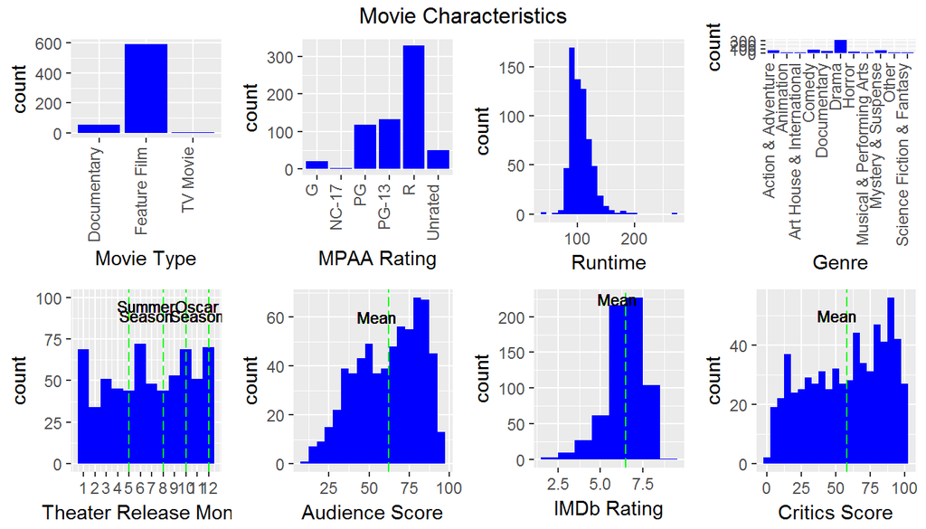

```r
p1 <- ggplot(data=movies, aes(x=genre)) +
      geom_bar(fill="blue") +
      xlab("Genre") +
      theme(axis.text.x=element_text(angle=90, hjust=1, vjust=0))
p2 <- ggplot(data=movies, aes(x=title_type)) +
      geom_bar(fill="blue") +
      xlab("Movie Type") +
      theme(axis.text.x=element_text(angle=90, hjust=1, vjust=0))
p3 <- ggplot(data=movies, aes(x=mpaa_rating)) +
      geom_bar(fill="blue") +
      xlab("MPAA Rating") +
      theme(axis.text.x=element_text(angle=90, hjust=1, vjust=0))
p4 <- ggplot(data=movies, aes(x=runtime)) +
      geom_histogram(binwidth=10, fill="blue") +
      xlab("Runtime")
p5 <- ggplot(data=movies, aes(x=thtr_rel_month)) +
      geom_histogram(binwidth=1, fill="blue") +
      scale_x_continuous(breaks=c(1:12)) +
      scale_y_continuous(limits=c(0, 100)) +
      geom_vline(xintercept=c(5, 8, 10, 12), colour='green', linetype='longdash') +
      geom_text(label='Summer', x=6.5, y=95, hjust='center', size=3) +
      geom_text(label='Oscar', x=11, y=95, hjust='center', size=3) +
      geom_text(label='Season', x=6.5, y=89, hjust='center', size=3) +
      geom_text(label='Season', x=11, y=89, hjust='center', size=3) +
      xlab("Theater Release Month")
p6 <- ggplot(data=movies, aes(x=audience_score)) +
      geom_histogram(binwidth=5, fill="blue") +
      geom_vline(xintercept=mean(movies$audience_score), colour='green', linetype='longdash') +
      geom_text(label='Mean', x=55, y=60, hjust='center', size=3) +
      xlab("Audience Score")
p7 <- ggplot(data=movies, aes(x=imdb_rating)) +
      geom_histogram(binwidth=1, fill="blue") +
      geom_vline(xintercept=mean(movies$imdb_rating), colour='green', linetype='longdash') +
      geom_text(label='Mean', x=6, y=225, hjust='center', size=3) +
      xlab("IMDb Rating")
p8 <- ggplot(data=movies, aes(x=critics_score)) +
      geom_histogram(binwidth=5, fill="blue") +
      geom_vline(xintercept=mean(movies$critics_score), colour='green', linetype='longdash') +
      geom_text(label='Mean', x=51, y=50, hjust='center', size=3) +
      xlab("Critics Score")

grid.arrange(p2, p3, p4, p1, p5, p6, p7, p8, ncol=4,
             top="Movie Characteristics")
```

The most common movie in the data set is a rated R, feature film, drama with a runtime of around 90 minutes. Approximately 32% of the movies were released during the summer season, and 29% of the movies were released during the Oscar season.

The distribution of audience scores shows an interesting bi-modality. As this is the value to be predicted by the model, one would like to see a normal distribution for this.

## Part 4: Modeling

The modeling goal was to predict the popularity of a movie - as quantified by the audience_score variable - using a linear regression model and bayesian model averaging.

The initial set of predictors chosen for the model were:

. `runtime` . `thtr_rel_year` . `imdb_rating` . `imdb_num_votes` . `critics_score` . `best_pic_nom` . `best_pic_win` . `best_actor_win` . `best_actress_win` . `best_dir_win` . `top200_box` . `feature_film` . `drama` . `mpaa_rating_R` . `oscar_season` . `summer_season`

As the first step, the data set was reduced to include only the response variable and the initial set of predictor variables.

```r
movies <- select(movies, runtime, thtr_rel_year, imdb_rating, imdb_num_votes,
                 critics_score, audience_score, best_pic_nom, best_pic_win,
                 best_actor_win, best_actress_win, best_dir_win, top200_box,
                 feature_film, drama, mpaa_rating_R, oscar_season, summer_season)
```

A bayesian linear regression model was created using all of the initial predictor variables. Because of the large number of predictors (leading to a very large number of possible model combinations), the Markov Chain Monte Carlo (MCMC) method was used for sampling models during the fitting process and the prior probabilities for the regression coefficients were assigned using the Zellner-Siow Cauchy distribution. A uniform distribution was used for the prior probabilities for all models.

```r
basLM1 <- bas.lm(audience_score ~ ., data=movies, method='MCMC',
                 prior='ZS-null', modelprior=uniform())
```

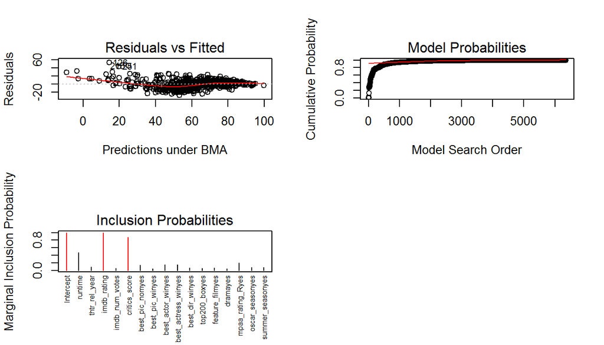

```r
par(mfrow=c(2,2))
plot(basLM1, which=c(1, 2), ask=FALSE)
plot(basLM1, which=4, ask=FALSE, cex.lab=0.5)
```

Shown above are diagnostic charts of the regression fitting process.

The top-left chart does not show a random scattering of the residuals versus the fitted values as one would like to see. There is a wave pattern indicating that the model tended to predict too low for ratings under a value of 30 and over a value of about 75. In between 30 and 75, the model tended to predict high. Above a rating of 75, the residuals appear to scatter randomly. This would indicate that perhaps some of the other predictor candidates should be further evaluated for inclusion in the model, or perhaps there is something else affecting the ratings that is not accounted for at all by the initial set of chosen predictors.

The bottom-left chart shows the inclusion probabilities for each of the predictors. How each predictor was used is shown graphically below for the top 20 models tested.

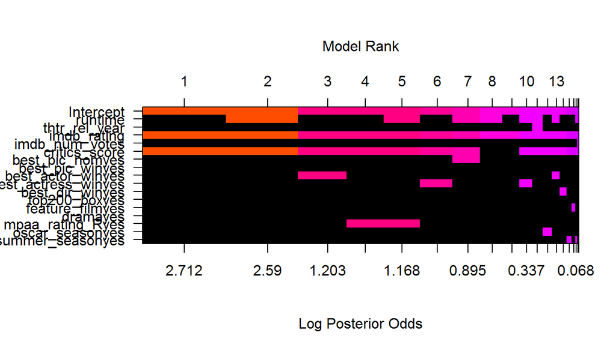

```r
image(basLM1, rotate=FALSE)
```

The model with the highest posterior probability (0.1404) contains only two of the predictors: imbd_rating and critics_score. The posterior distributions of the regression coefficients are shown below. The vertical line at 0 on the X axis indicates the posterior probability of the coefficient being zero (i.e., that the particular predictor would not be included in any model).

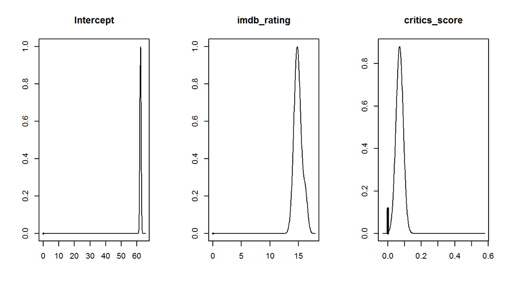

```r
par(mfrow=c(1,3))
plot(coefficients(basLM1), subset=c(1, 4, 6), ask=FALSE)
```

It is noteworthy that the distribution for imdb_rating does not visually look entirely normal as there appears to be a small non-symmetric bump on the right side. Possible reasons for this were not explored; although it could be related to the wave pattern shown on the residuals plot above or the non-normal distribution of audience score values.

Credible intervals were determined by using the model to predict the same audience scores as were used to fit the model originally. Below are shown the intervals for the fitted and predicted values.

```r
BMA_basLM1 = predict(basLM1, estimator="BMA", se.fit=TRUE)
BMA_confint_fit = confint(BMA_basLM1, parm="mean")
BMA_confint_pred = confint(BMA_basLM1, parm="pred")
head(cbind(BMA_confint_fit, BMA_confint_pred), 10)
```

```
##         2.5  %  97.5  %     mean   2.5  %   97.5  %     pred
##  [1,] 45.23909 49.07379 47.20258 26.93508  66.49927 47.20258
##  [2,] 75.10285 78.98445 77.14571 57.40756  97.01032 77.14571
##  [3,] 79.49242 83.81131 81.55115 61.93788 101.59632 81.55115
##  [4,] 70.41754 75.70754 73.23433 53.19594  93.11153 73.23433
##  [5,] 38.52637 41.79076 40.23986 20.76324  60.74609 40.23986
##  [6,] 82.55648 87.38474 84.95282 65.01187 104.26905 84.95282
##  [7,] 69.58878 74.73362 72.24688 52.18748  91.65782 72.24688
##  [8,] 42.19241 47.40836 44.84074 24.15062  63.86494 44.84074
##  [9,] 78.12377 82.27512 80.13071 60.97483 100.76163 80.13071
## [10,] 62.98777 67.38028 65.34738 45.33075  84.76524 65.34738
```

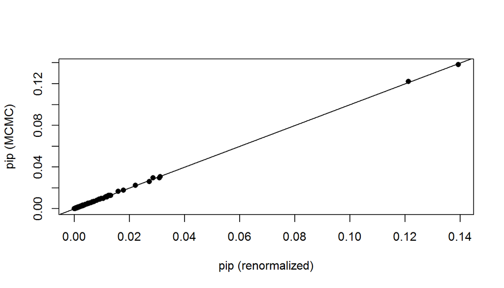

```r
diagnostics(basLM1, type="model",  pch=16)
```

## Part 5: Prediction

The predictive capability of bayesian model averaging was tested using data for a movie that was not included in the analysis data set. The movie chosen was Deadpool which was released early in 2016. An early release date was chosen to give time for the movie to have been in the theaters for a while and for the ratings to mature. The information for this movie was obtained from the IMDb and Rotten Tomatoes web sites in order to be consistent with the analysis data

http://www.imdb.com/title/tt1431045/

https://www.rottentomatoes.com/m/deadpool

The results are shown below.

```r
dfDeadpool <- data.frame(runtime=108,
                         thtr_rel_year=2016,
                         imdb_rating=8.1,
                         imdb_num_votes=500049,
                         critics_score=84,
                         audience_score=0,
                         best_pic_nom=factor("no", levels=c("no", "yes")),
                         best_pic_win=factor("no", levels=c("no", "yes")),
                         best_actor_win=factor("no", levels=c("no", "yes")),
                         best_actress_win=factor("no", levels=c("no", "yes")),
                         best_dir_win=factor("no", levels=c("no", "yes")),
                         top200_box=factor("no", levels=c("no", "yes")),
                         feature_film=factor("yes", levels=c("no", "yes")),
                         drama=factor("no", levels=c("no", "yes")),
                         mpaa_rating_R=factor("yes", levels=c("no", "yes")),
                         oscar_season=factor("no", levels=c("no", "yes")),
                         summer_season=factor("no", levels=c("no", "yes")))

BMA_basLM1_DP <- predict(basLM1, newdata=dfDeadpool, estimator="BMA", se.fit=TRUE)

BMA_basLM1_predME <- qt(0.95, df=BMA_basLM1_DP$se.bma.pred[1]) *
                     mean(BMA_basLM1_DP$se.bma.pred)

df <- data.frame(t="Deadpool",
                 p=sprintf("%2.1f", BMA_basLM1_DP$Ybma),
                 i=sprintf("%2.1f - %2.1f", BMA_basLM1_DP$Ybma - BMA_basLM1_predME,
                           BMA_basLM1_DP$Ybma + BMA_basLM1_predME),
                 r=84)
colnames(df) <- c("Movie Title", "Predicted Rating", "95% Prediction Interval",
                  "Actual Rating")
print(df)
```

```
##   Movie Title Predicted Rating 95% Prediction Interval Actual Rating
## 1    Deadpool             87.9            69.6 - 106.2            84
```

## Part 6: Conclusion

In this analysis, a parsimonious, linear regression model using bayesian model averaging was created that proved to have some capability for predicting movie popularity based on certain movie characteristics.

But, there is much room for further analysis in at least the following areas. 1. Why is does the `imdb_rating` regression coefficient distribution not show a normal curve? Is it related to the non-normal distribution of audience score values?

2. What is the nature of the wave pattern in the residuals plot?
3. Would it be better to create separate models for each movie type or genre? Would doing so eliminate the non-normal distribution of audience score values in the analysis data?
4. How should sequels be handled?